# 코로나 정책 전후 비교를 통해 확진 예방에 얼마나 도움이 되었는가?

- 1. 교육부 정책(개학연기, 온라인 개학)
- 1. 해외입국 관련 정책(의무 2주 자가 격리)

### 1. 교육부 정책(초중고, 대학교)

- 1) 타겟이 되는 확진자 나이를 10s, 20s 로 분류해 보았음
  - 0s의 경우 확진자 수가 적으며 0s 일 경우 독립적으로 활동할 가능성이 적다고 판단
  - 활동성이 있는 초등학교(3학년 ~ 6학년) 인구도 10s에 초함되어 있다고 생각
- 2) 3월 2일 개강 연기 후 전학년 개강 까지 날짜를 3단계로 나누어 진행
  - ~5월 19일 (온라인 교육 실시)
  - 5월 20일 ~ 6월 8일 (학년별 개강)
  - 6월 9일 ~ 6월 30일(PatientInfo의 마지막 날짜)(전 학년 격일 격주 등교)
- 3) city 별 확진자 수 대신 province (서울,경기,경상북도, 인천)지역별 확진추이 판단
  - 상위 그룹에 있는 서울 경기 경북, 인천지역 으로 진행했음

```python
import pandas as pd
import numpy as  np
from datetime import datetime
from datetime import timedelta
import matplotlib.pyplot as plt
plt.rcParams['font.family']='Malgun Gothic'

%matplotlib inline
```

### 정책 일지

```python
policy = pd.read_csv('C:/Users/82109/코로나 프로젝트 파이썬 파일/cleansed_data/policy.csv')
```

```python
policy[policy.type =="Education"]
```

|  | policy_id | country | type | gov_policy | detail | start_date | end_date |
| --- | --- | --- | --- | --- | --- | --- | --- |
| 33 | 34 | 대한민국 | Education | School Closure | Daycare Center for Children | 2020-03-02 | NaN |
| 34 | 35 | 대한민국 | Education | School Opening Delay | Kindergarten | 2020-03-02 | 2020-04-06 |
| 35 | 36 | 대한민국 | Education | School Opening Delay | High School | 2020-03-02 | 2020-04-06 |
| 36 | 37 | 대한민국 | Education | School Opening Delay | Middle School | 2020-03-02 | 2020-04-06 |
| 37 | 38 | 대한민국 | Education | School Opening Delay | Elementary School | 2020-03-02 | 2020-04-06 |
| 38 | 39 | 대한민국 | Education | School Opening with Online Class | High School (3rd grade) | 2020-04-09 | 2020-05-20 |
| 39 | 40 | 대한민국 | Education | School Opening with Online Class | High School (2nd grade) | 2020-04-16 | 2020-05-27 |
| 40 | 41 | 대한민국 | Education | School Opening with Online Class | High School (1st grade) | 2020-04-16 | 2020-06-03 |
| 41 | 42 | 대한민국 | Education | School Opening with Online Class | Middle School (3rd grade) | 2020-04-09 | 2020-05-27 |
| 42 | 43 | 대한민국 | Education | School Opening with Online Class | Middle School (2nd grade) | 2020-04-16 | 2020-06-03 |
| 43 | 44 | 대한민국 | Education | School Opening with Online Class | Middle School (1st grade) | 2020-04-16 | 2020-06-08 |
| 44 | 45 | 대한민국 | Education | School Opening with Online Class | Elementary School (5th ~ 6th grade) | 2020-04-16 | 2020-06-08 |
| 45 | 46 | 대한민국 | Education | School Opening with Online Class | Elementary School (4th grade) | 2020-04-16 | 2020-06-03 |
| 46 | 47 | 대한민국 | Education | School Opening with Online Class | Elementary School (3rd grade) | 2020-04-20 | 2020-06-03 |
| 47 | 48 | 대한민국 | Education | School Opening with Online Class | Elementary School (1st ~ 2nd grade) | 2020-04-20 | 2020-05-27 |

### 환자 데이터

```python
c_patient_info= pd.read_csv('C:/Users/82109/코로나 프로젝트 파이썬 파일/cleansed_data/PatientInfo.csv')
```

```python
# 이후 과정에 데이터를 통합 하기위해 80이상을 모두 80s 로 변경
c_patient_info['age'] = c_patient_info['age'].apply(lambda x: '80s' if (x == '90s' or x=='100s') else x)
```

```python
c_patient_info['num']=1
```

### 타겟 나이 설정(10s,20s)

```python
c_patient_target = c_patient_info[c_patient_info['age'].isin(['10s', '20s'])]
```

```python
c_patient_target.head()
```

|  | patient_id | sex | age | country | province | city | infection_case | confirmed_date | state | country_국내외 | num |
| --- | --- | --- | --- | --- | --- | --- | --- | --- | --- | --- | --- |
| 3 | 1000000004 | male | 20s | 대한민국 | 서울 | 마포구 | overseas inflow | 2020-01-30 | released | 국내 | 1 |
| 4 | 1000000005 | female | 20s | 대한민국 | 서울 | 성북구 | contact with patient | 2020-01-31 | released | 국내 | 1 |
| 6 | 1000000007 | male | 20s | 대한민국 | 서울 | 종로구 | contact with patient | 2020-01-31 | released | 국내 | 1 |
| 7 | 1000000008 | male | 20s | 대한민국 | 서울 | 기타 | overseas inflow | 2020-02-02 | released | 국내 | 1 |
| 11 | 1000000012 | male | 20s | 대한민국 | 서울 | 기타 | overseas inflow | 2020-02-07 | released | 국내 | 1 |

```python
province_visual = pd.pivot_table(c_patient_target,index=['province'],columns=['age'],values = 'num',aggfunc='sum').fillna(0)
```

```
array([<matplotlib.axes._subplots.AxesSubplot object at 0x000002AED1EF9FC8>,
      dtype=object)
```

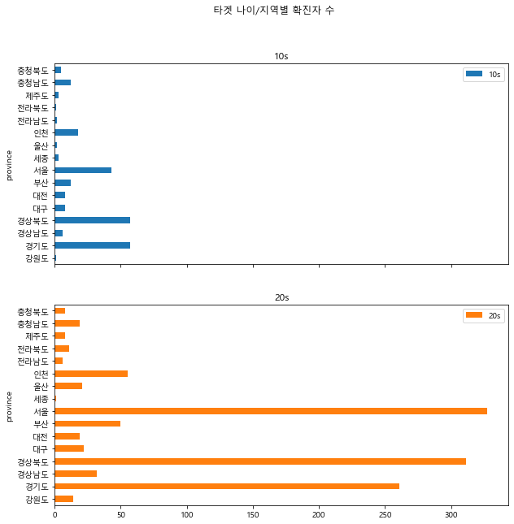

```python
province_visual.plot(kind = 'barh',subplots = True,title = '타겟 나이/지역별 확진자 수',figsize=(10, 10))
```

- 공통적으로 상위 4가지 지역인 서울, 경북, 경기, 인천에 대해서 분석을 진행하기로 결정

### 전체적인 형태

- 날짜별 확진자 추이 분석
- 감염 원인 분석
- 10,20세 별 원인 분석
- 정책 시기별 이유 분석

```python
target_patient_all_visual = pd.pivot_table(c_patient_target,index=['confirmed_date'],columns=['age'],values='num',aggfunc='sum').fillna(0)
```

```
array([<matplotlib.axes._subplots.AxesSubplot object at 0x000002AED295F848>,
      dtype=object)
```

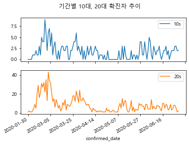

```python
target_patient_all_visual.plot(subplots = True, title = '기간별 10대, 20대 확진자 추이 ')
```

```python
patient_target_all_reason = c_patient_target.infection_case.value_counts().sort_values(ascending=False)
```

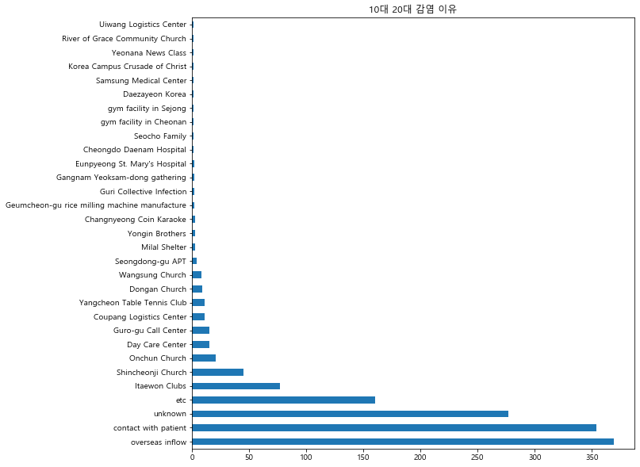

```python
patient_target_all_reason.plot(kind='barh',figsize=(10, 10),title = '10대 20대 감염 이유')
```

- etc, unknown, contact with patient가 개학에 영향이 있을까?

```python
# 10s 이유 분석
all_10_patient = c_patient_target[c_patient_target.age=='10s']
```

```python
all_10_patient_reason = all_10_patient.infection_case.value_counts().sort_values(ascending=False)
```

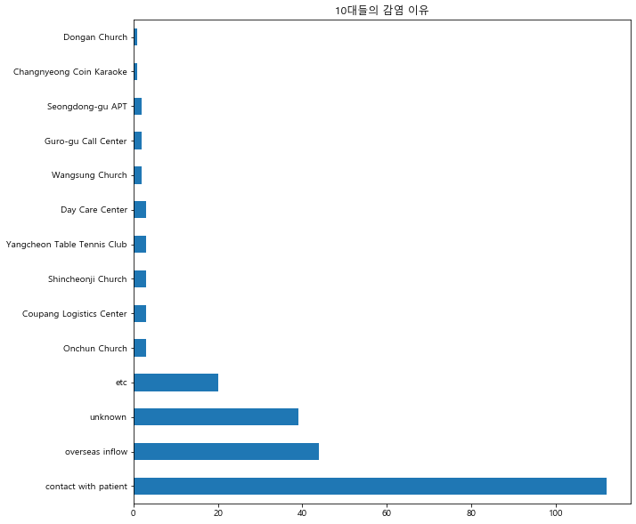

```python
all_10_patient_reason.plot(kind='barh',figsize=(10, 10),title = '10대들의 감염 이유')
```

```python
# 20s 이유 분석
all_20_patient = c_patient_target[c_patient_target.age=='20s']
```

```python
all_20_patient_reason = all_20_patient.infection_case.value_counts().sort_values(ascending=False)
```

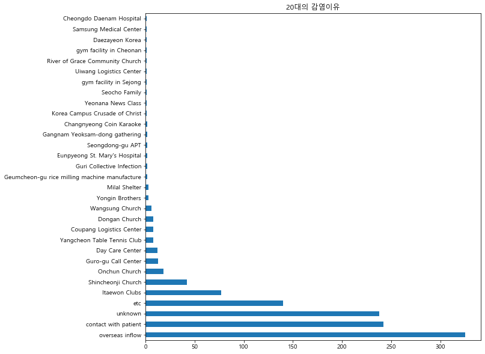

```python
all_20_patient_reason.plot(kind='barh',figsize=(10, 10),title = '20대의 감염이유')
```

### etc, unknown, contact with patient 이 개학과 가장 연관성 높은 이유라 판단

### 밑에 코드 고쳐주세요

```python
all_patient_related_reason = \
c_patient_target[(c_patient_target.infection_case == 'etc') |
                 (c_patient_target.infection_case == 'unknown') |
                 (c_patient_target.infection_case == 'contact with patient')]
```

```python
all_patient_related_reason
```

|  | patient_id | sex | age | country | province | city | infection_case | confirmed_date | state | country_국내외 | num |
| --- | --- | --- | --- | --- | --- | --- | --- | --- | --- | --- | --- |
| 4 | 1000000005 | female | 20s | 대한민국 | 서울 | 성북구 | contact with patient | 2020-01-31 | released | 국내 | 1 |
| 6 | 1000000007 | male | 20s | 대한민국 | 서울 | 종로구 | contact with patient | 2020-01-31 | released | 국내 | 1 |
| 17 | 1000000018 | male | 20s | 대한민국 | 서울 | 기타 | etc | 2020-02-20 | released | 국내 | 1 |
| 33 | 1000000034 | male | 20s | 대한민국 | 서울 | 송파구 | contact with patient | 2020-02-24 | released | 국내 | 1 |
| 45 | 1000000046 | female | 20s | 대한민국 | 서울 | 기타 | contact with patient | 2020-02-26 | released | 국내 | 1 |
| ... | ... | ... | ... | ... | ... | ... | ... | ... | ... | ... | ... |
| 5029 | 6100000115 | male | 20s | 대한민국 | 경상남도 | 창원시 | etc | 2020-04-16 | released | 국내 | 1 |
| 5037 | 6100000123 | female | 20s | 대한민국 | 경상남도 | 김해시 | etc | 2020-06-05 | released | 국내 | 1 |
| 5040 | 6100000126 | female | 10s | 대한민국 | 경상남도 | 양산 | etc | 2020-06-09 | isolated | 국내 | 1 |
| 5048 | 7000000001 | male | 20s | 대한민국 | 제주도 | 제주도 | etc | 2020-02-20 | released | 국내 | 1 |
| 5049 | 7000000002 | female | 20s | 대한민국 | 제주도 | 제주도 | etc | 2020-02-22 | released | 국내 | 1 |

791 rows × 11 columns

```python
target_patient_top_reason_visual = pd.pivot_table(all_patient_related_reason,index=['confirmed_date'],columns=['age','infection_case'],values='num',aggfunc='sum').fillna(0)
```

```
array([<matplotlib.axes._subplots.AxesSubplot object at 0x000001CF372BF308>,
      dtype=object)
```

[figure not shown]

```python
target_patient_top_reason_visual.plot(subplots=True)
```

### 기간을 나눠서 이유 분석

### 개강이전, 학년별 개강, 전학년 등교 3가지

```python
# 개강 이전
target_patient_pre = c_patient_target[c_patient_target.confirmed_date<='2020-05-19']
len(target_patient_pre)
```

```
1085
```

```python
# 학년별 개강
target_patient_mid = c_patient_target[c_patient_target.confirmed_date<='2020-06-08']
target_patient_mid = target_patient_mid[c_patient_target.confirmed_date>='2020-05-20']
len(target_patient_mid)
```

```
153
```

```python
# 전학년 등교
target_patient_all = c_patient_target[c_patient_target.confirmed_date>='2020-06-09']
len(target_patient_all)
```

```
165
```

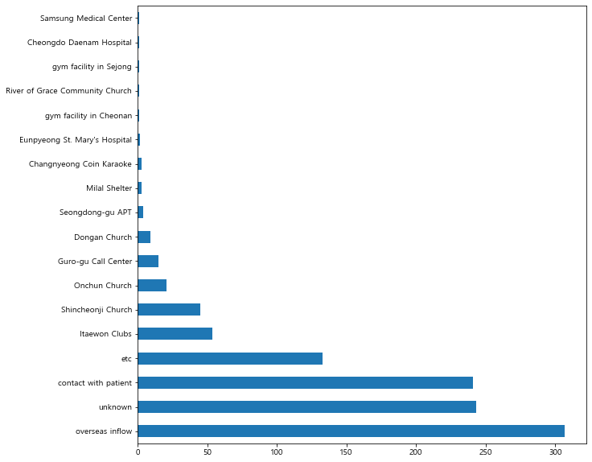

```python
# 개강이전 이유

all_target_patient_pre_reason = target_patient_pre.infection_case.value_counts().sort_values(ascending=False)
all_target_patient_pre_reason.plot(kind='barh',figsize=(10, 10))
```

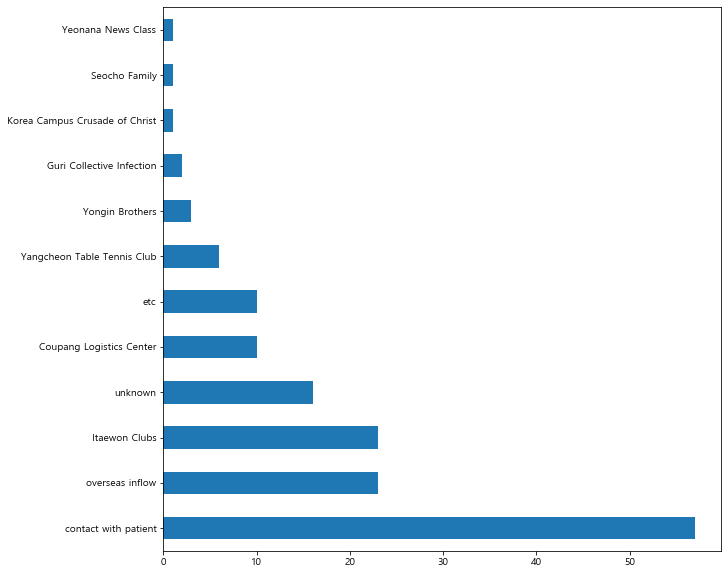

```python
# 학년별 개강 이유

all_target_patient_mid_reason = target_patient_mid.infection_case.value_counts().sort_values(ascending=False)
all_target_patient_mid_reason.plot(kind='barh',figsize=(10, 10))
```

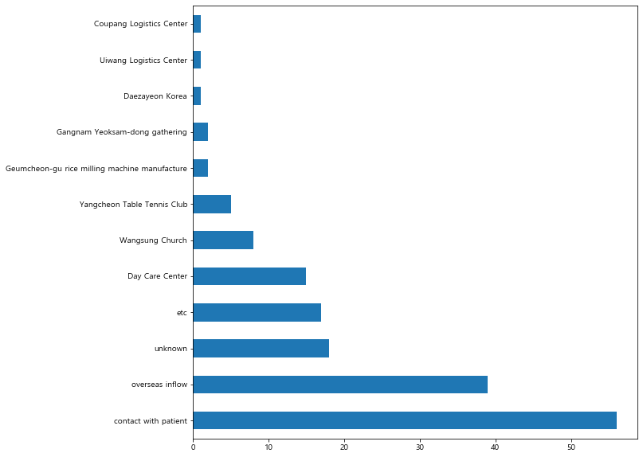

```python
# 전학년 등교

all_target_patient_all_reason = target_patient_all.infection_case.value_counts().sort_values(ascending=False)
all_target_patient_all_reason.plot(kind='barh',figsize=(10, 10))
```